# Puppy Breed Analysis

Tom Kremer

Last Updated: 2026-01-04

### Preprocessing Notes

1. This page shows the results for the questions of interest split by the breed of the puppy - Pure, Designer, Mixed Breed. The overall structure and design is the same as the source analysis file.

## S3

**S3: How old was your puppy when first brought home?**

4002 non-empty/NA responses out of 4002 possible responses ( 100 %)

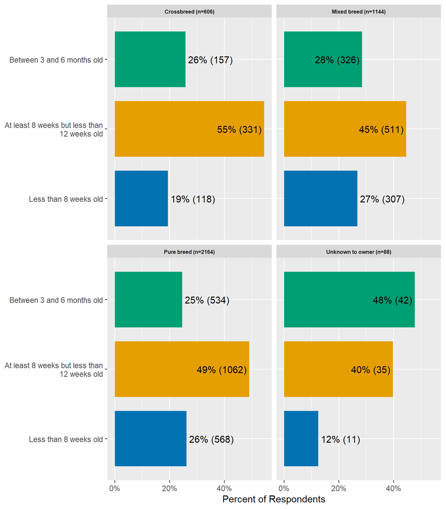

## S5

**S5: What is your age, in years?**

4002 non-empty/NA responses out of 4002 possible responses ( 100 %)

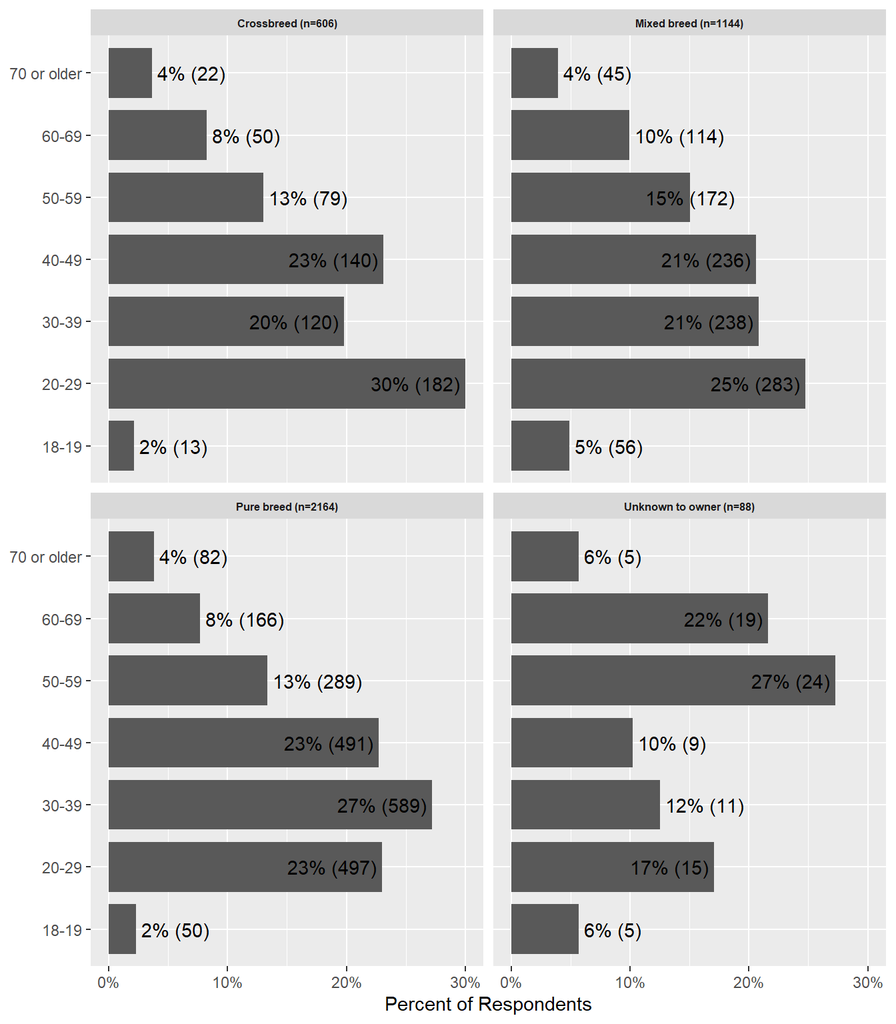

## Q3

**Q3: What is your puppy’s expected size when fully grown?**

4002 non-empty/NA responses out of 4002 possible responses ( 100 %)

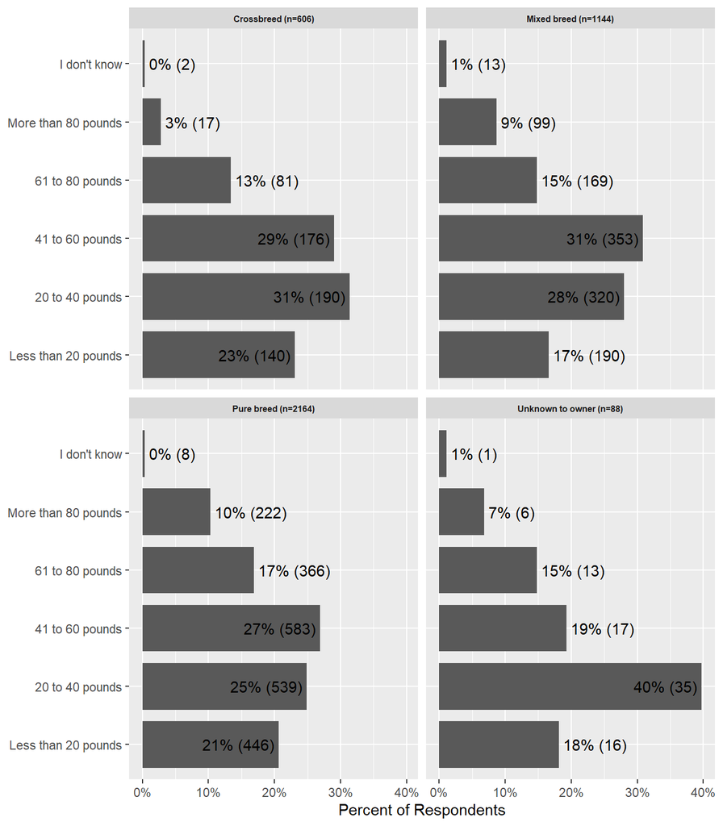

## Q5

**What information do you have on your puppy’s breed?**

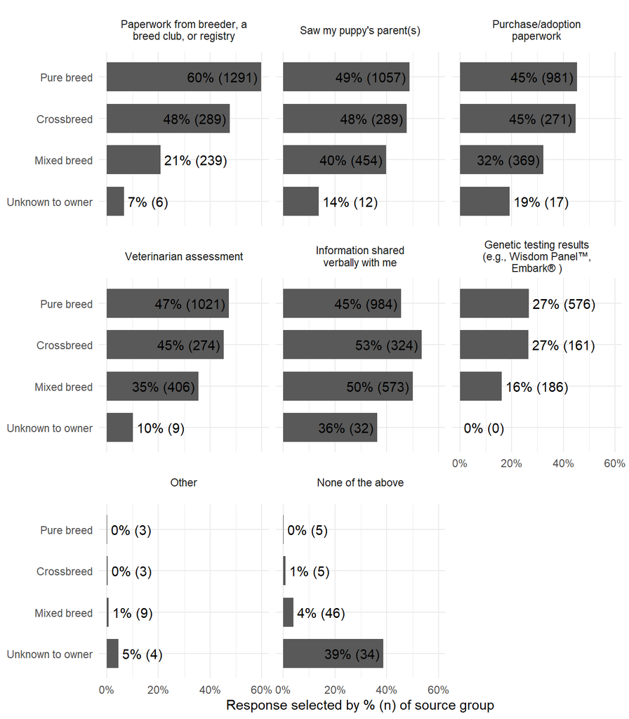

## Q12 (…)

**Q12: Is your puppy sterilized (spayed or neutered)?**

4002 non-empty/NA responses out of 4002 possible responses ( 100 %)

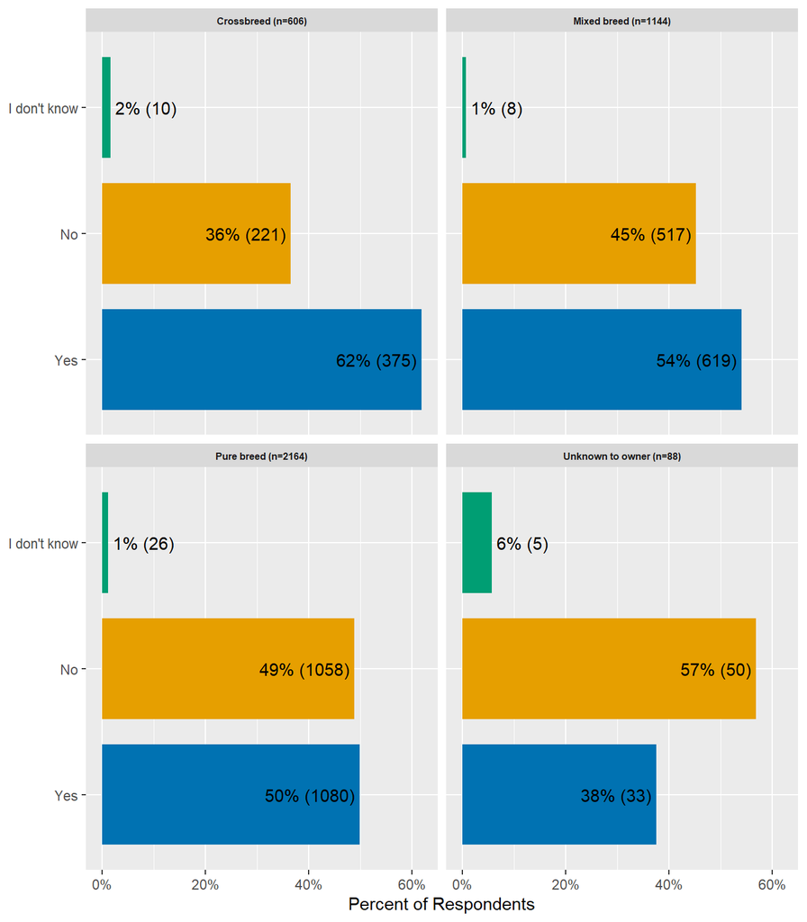

### > Q13

**Q13: Was your puppy sterilized before you brought them home?**

2107 non-empty/NA responses out of 2107 possible responses ( 100 %)

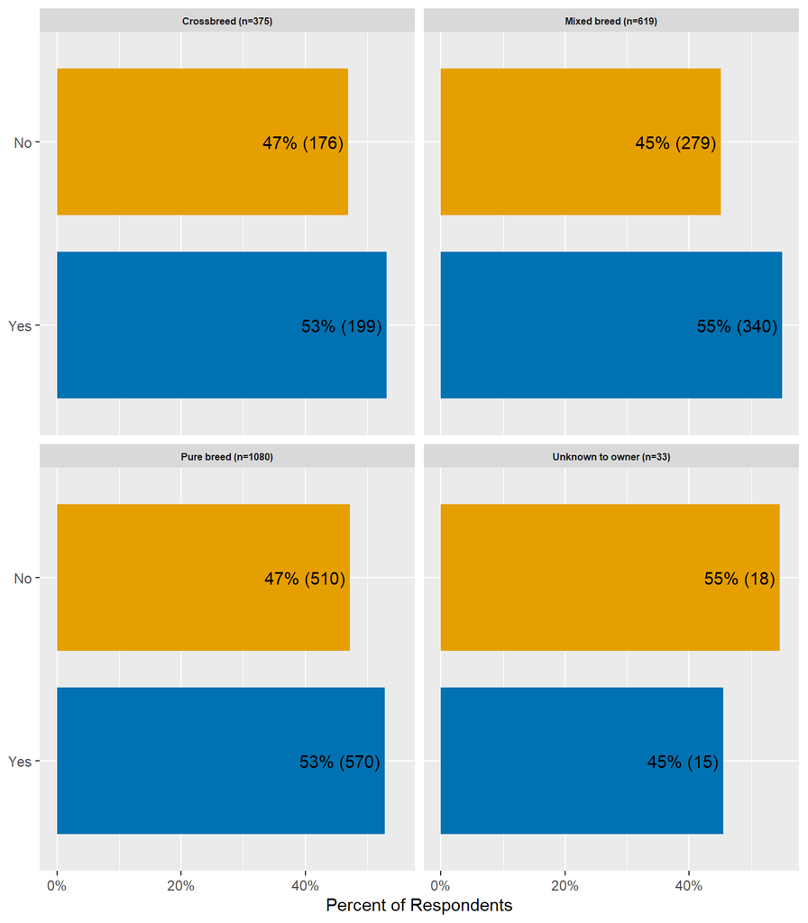

### > Q14

**Q14: Do you plan to breed your puppy in the future?**

1846 non-empty/NA responses out of 1895 possible responses ( 97 %)

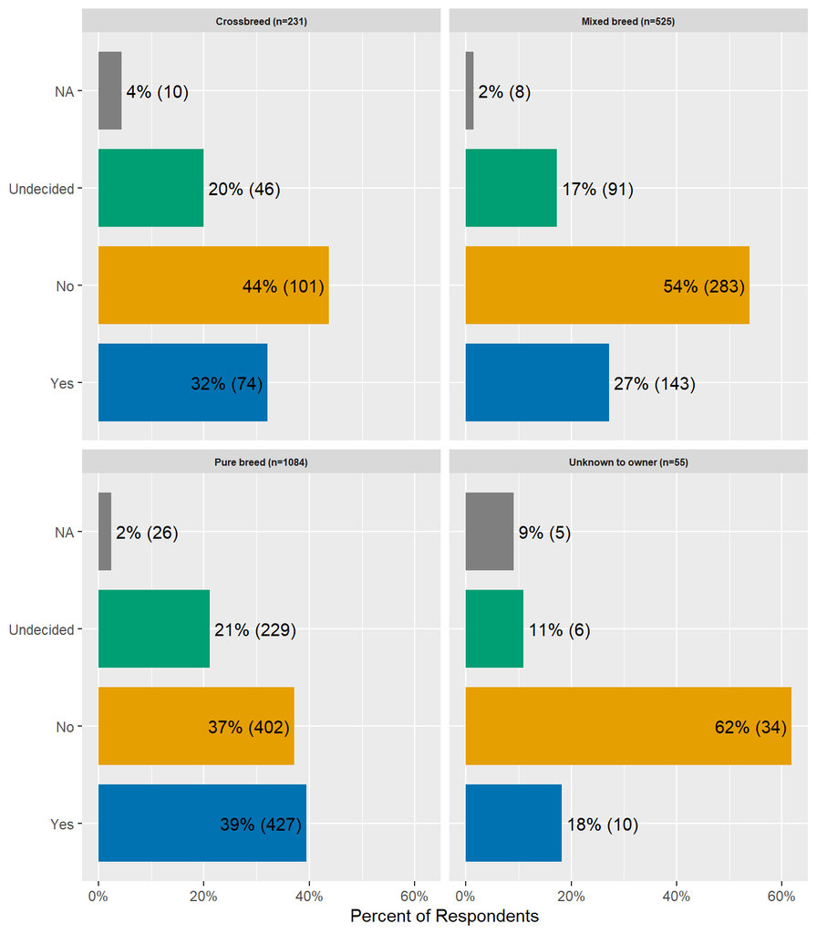

## Q17

**Q17: Before this puppy, were you ever a primary caretaker for a dog as an adult (when you were age 18 or older)?**

4002 non-empty/NA responses out of 4002 possible responses ( 100 %)

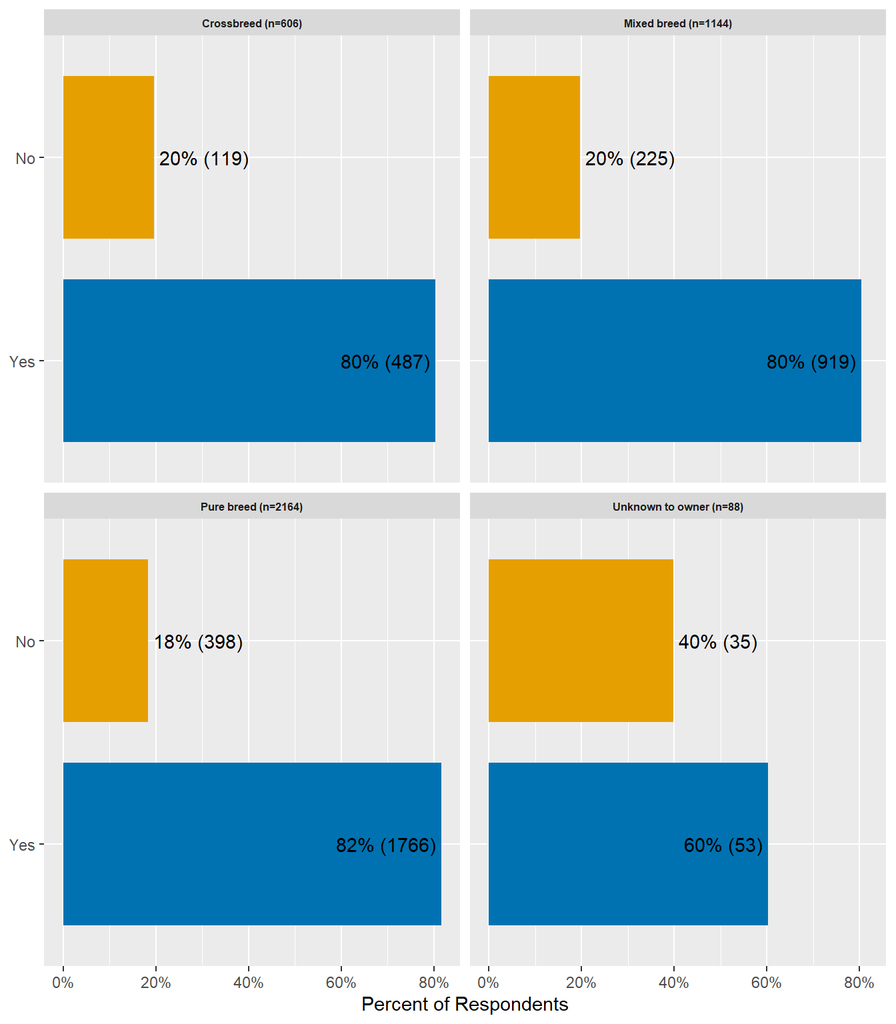

## Group A Only (…)

**Group A Only**

### > Q18

**Q18: How much time did you spend searching for a puppy?**

2001 non-empty/NA responses out of 2001 possible responses ( 100 %)

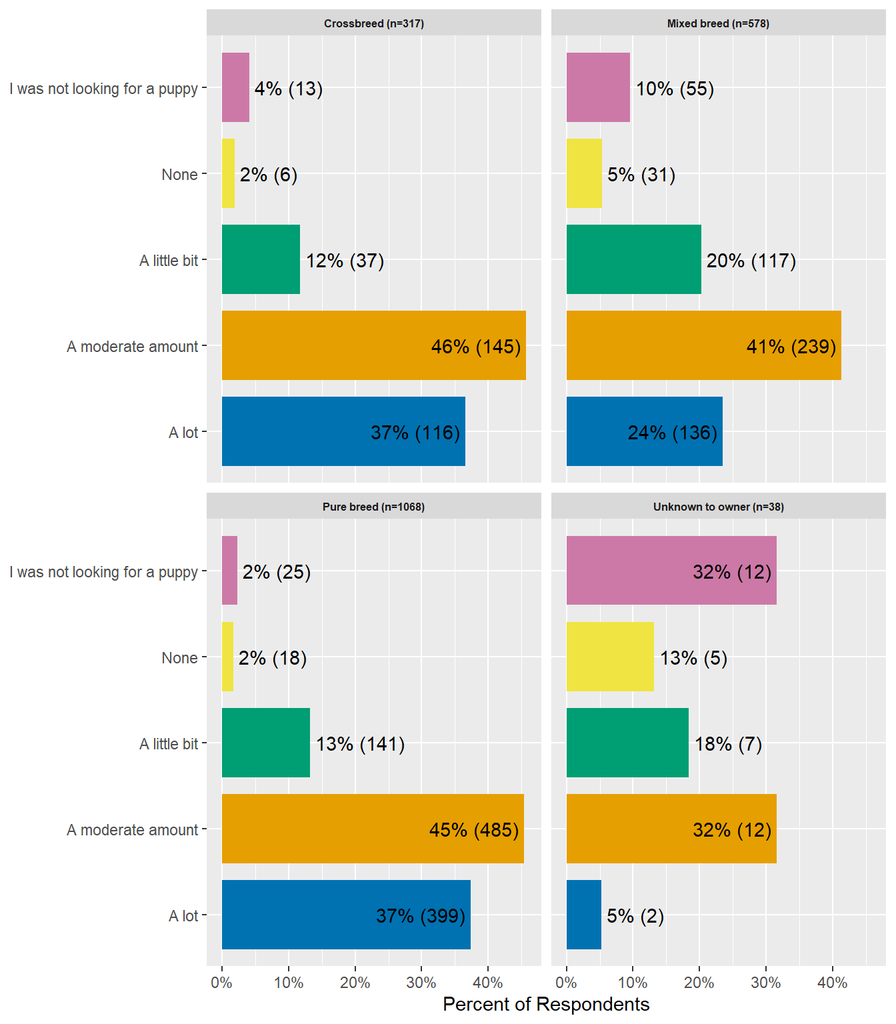

### > Q24

**Q24: How closely did the puppy you got match what you were searching for?**

1896 non-empty/NA responses out of 1896 possible responses ( 100 %)

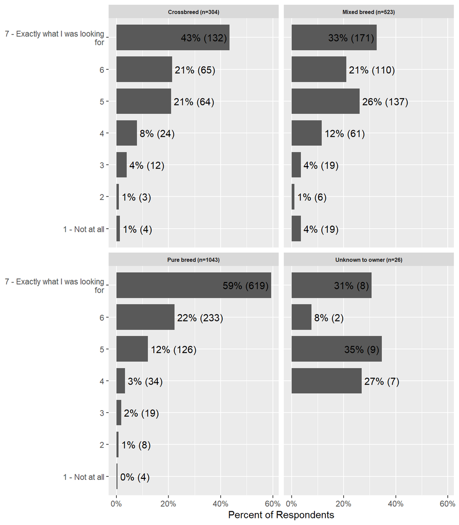

### > Q25

**Q25r1: I wanted a puppy from a specific source (e.g., shelter, breeder, etc.) - How important were each of the following in choosing your puppy?**

1896 non-empty/NA responses out of 1896 possible responses ( 100 %)

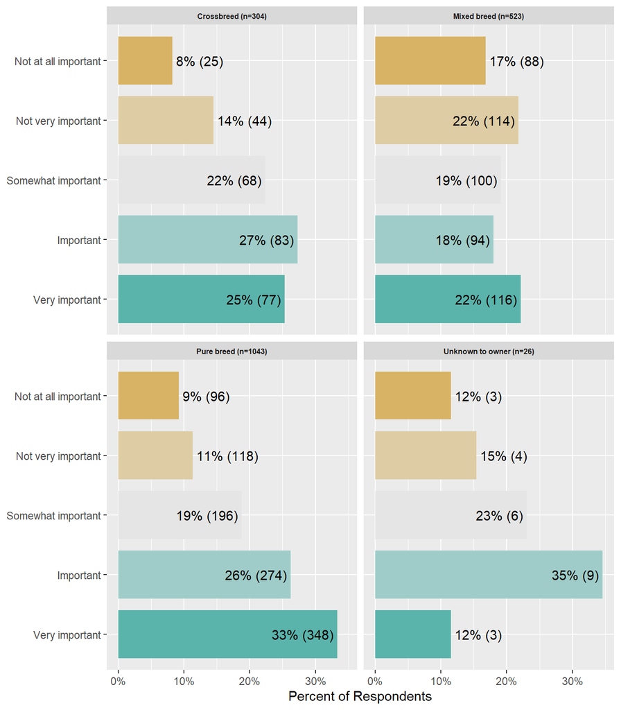

### > Q25r2

**Q25r2: I wanted a puppy that was a specific age - How important were each of the following in choosing your puppy?**

1896 non-empty/NA responses out of 1896 possible responses ( 100 %)

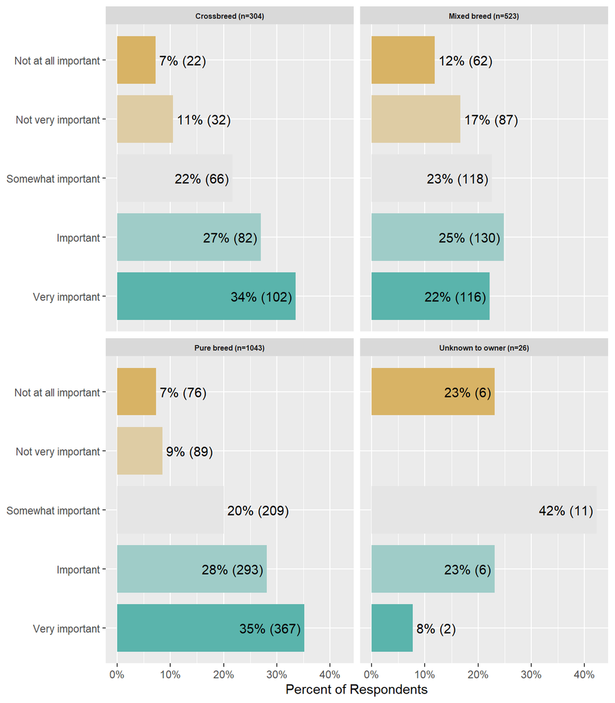

### > Q25r3

**Q25r3: I wanted a puppy that would grow to a certain size (e.g., tiny, small, medium, large) - How important were each of the following in choosing your puppy?**

1896 non-empty/NA responses out of 1896 possible responses ( 100 %)

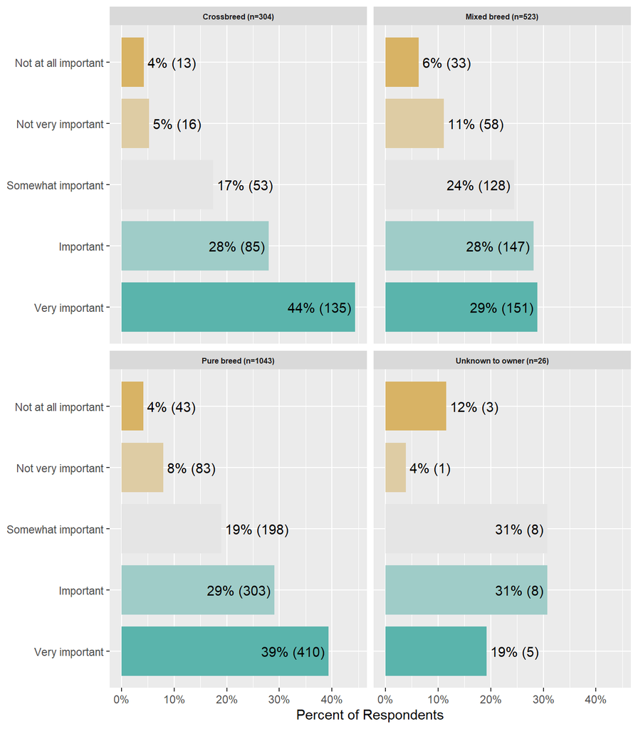

### > Q25r4

**Q25r4: I wanted a particular breed or breed type - How important were each of the following in choosing your puppy?**

1896 non-empty/NA responses out of 1896 possible responses ( 100 %)

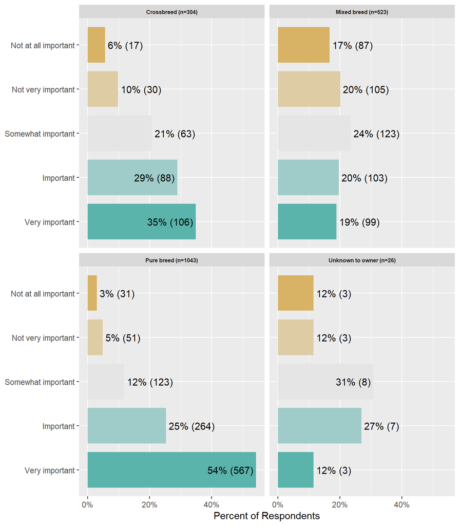

### > Q25r5

**Q25r5: I wanted to have an emotional connection to my puppy - How important were each of the following in choosing your puppy?**

1896 non-empty/NA responses out of 1896 possible responses ( 100 %)

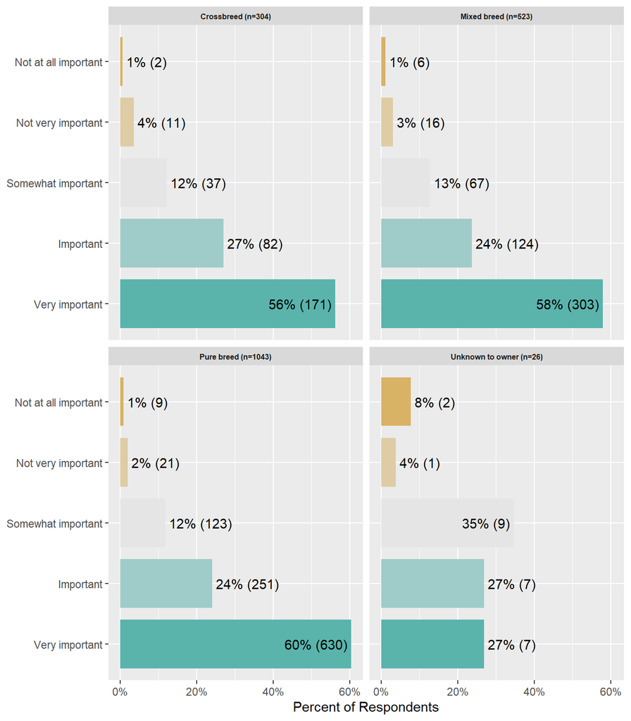

### > Q25r6

**Q25r6: I wanted a puppy from a source that I trust - How important were each of the following in choosing your puppy?**

1896 non-empty/NA responses out of 1896 possible responses ( 100 %)

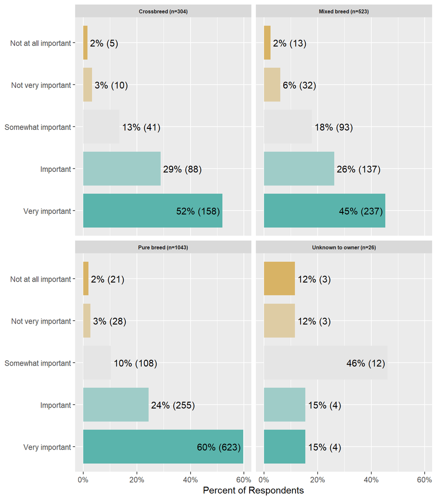

### > Q25r7

**Q25r7: I wanted a puppy that was hypoallergenic - How important were each of the following in choosing your puppy?**

1896 non-empty/NA responses out of 1896 possible responses ( 100 %)

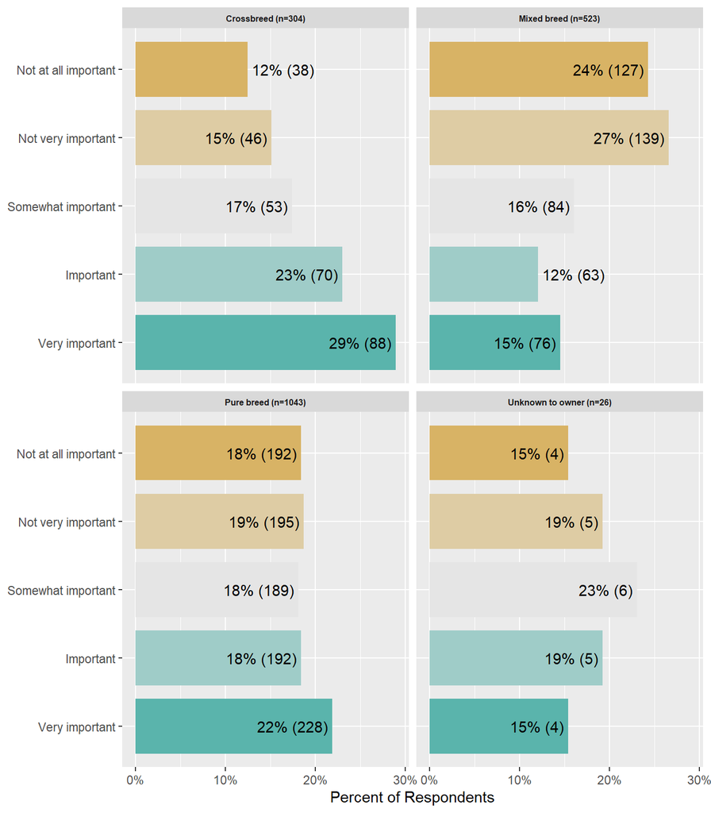

### > Q25r8

**Q25r8: I wanted a puppy with a particular fur color (e.g., black, white, golden, brown, mixed, etc.) - How important were each of the following in choosing your puppy?**

1896 non-empty/NA responses out of 1896 possible responses ( 100 %)

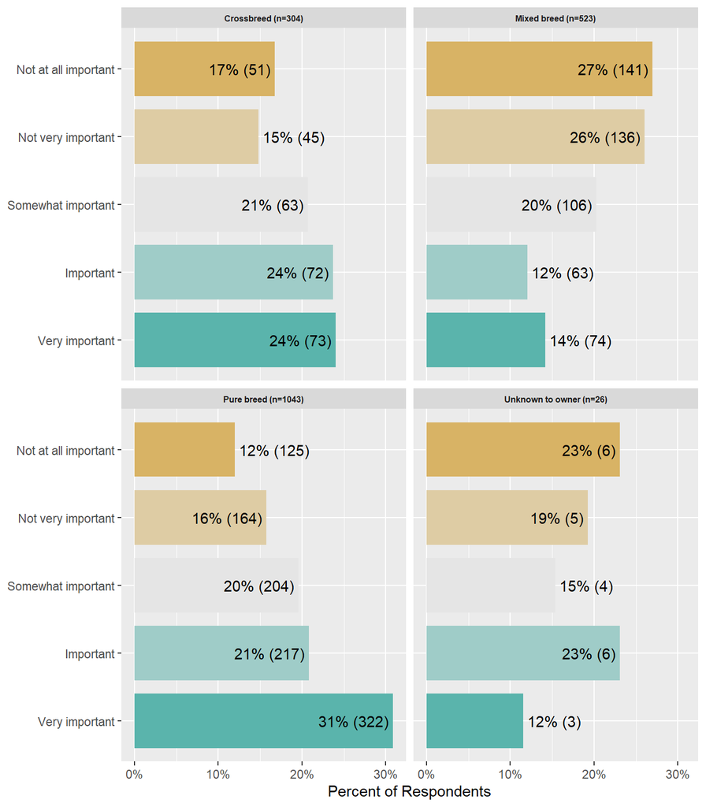

### > Q28

**Q28r1: Convenience - How important were the following things in deciding where you got your puppy?**

1896 non-empty/NA responses out of 1896 possible responses ( 100 %)

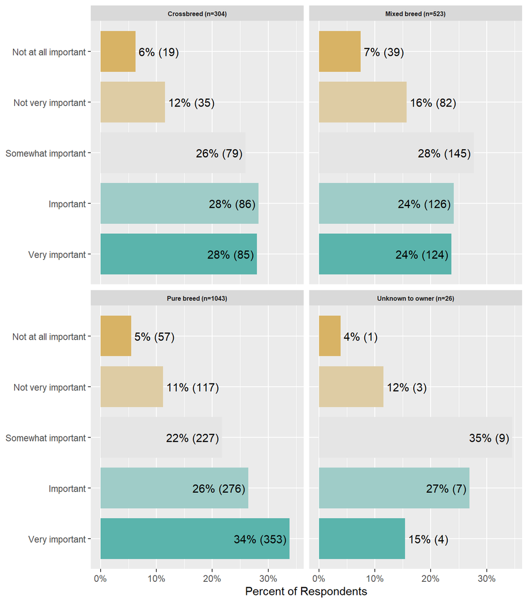

### > Q28r2

**Q28r2: The degree to which the puppy was already socialized - How important were the following things in deciding where you got your puppy?**

1896 non-empty/NA responses out of 1896 possible responses ( 100 %)

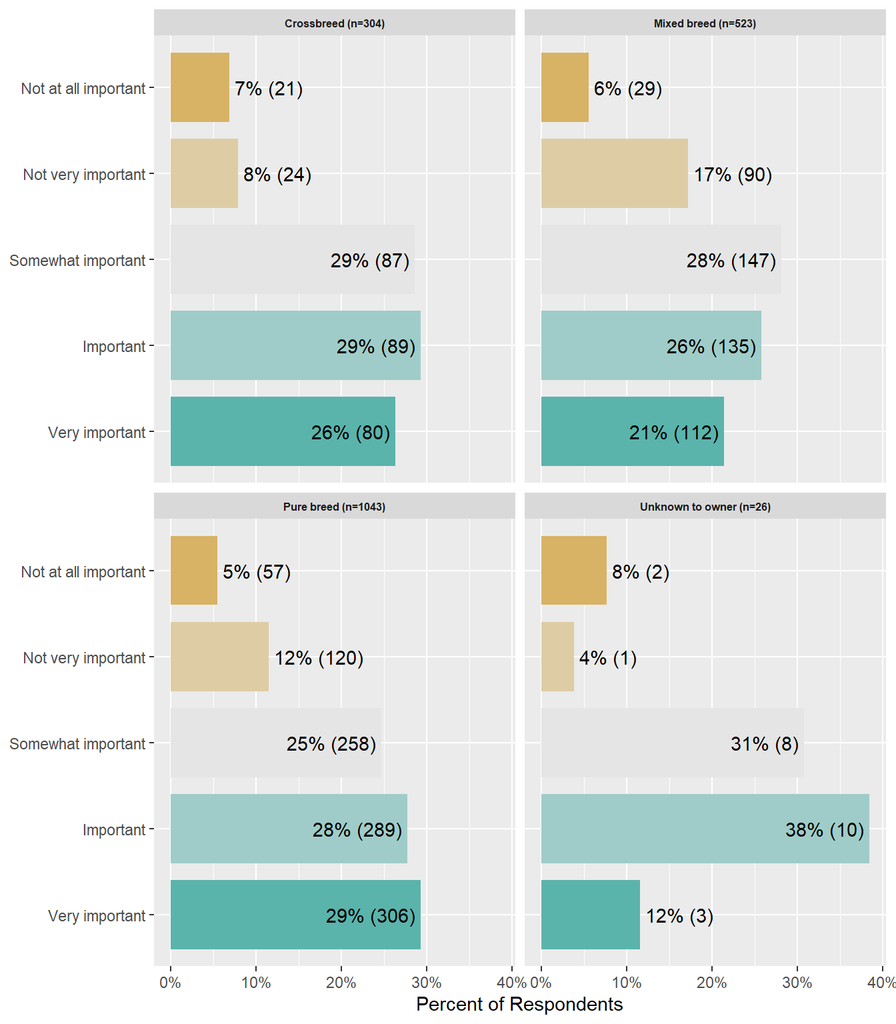

### > Q28r3

**Q28r3: Getting a puppy that is homeless or in need of a home - How important were the following things in deciding where you got your puppy?**

1896 non-empty/NA responses out of 1896 possible responses ( 100 %)

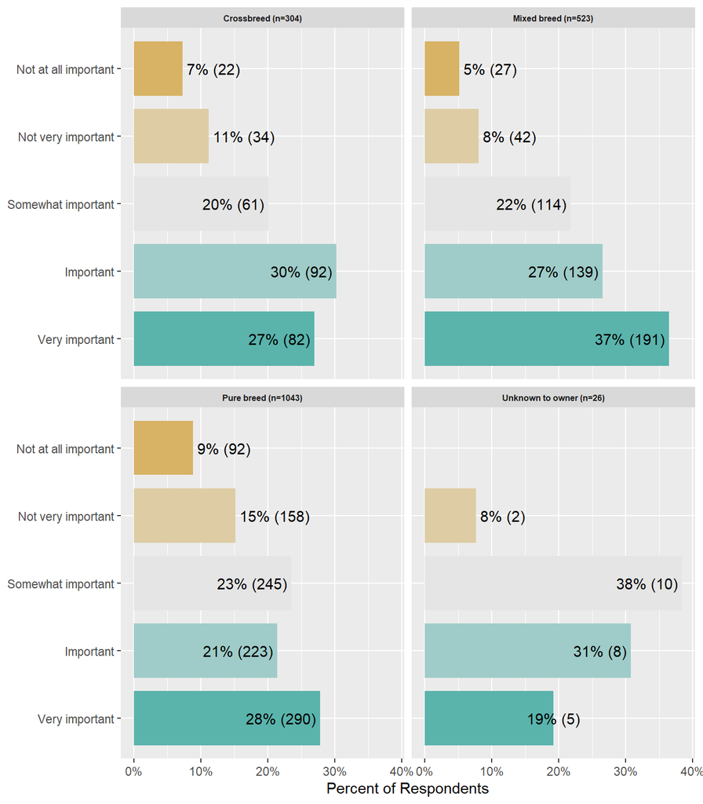

### > Q28r4

**Q28r4: Ability to bring puppy home quickly - How important were the following things in deciding where you got your puppy?**

1896 non-empty/NA responses out of 1896 possible responses ( 100 %)

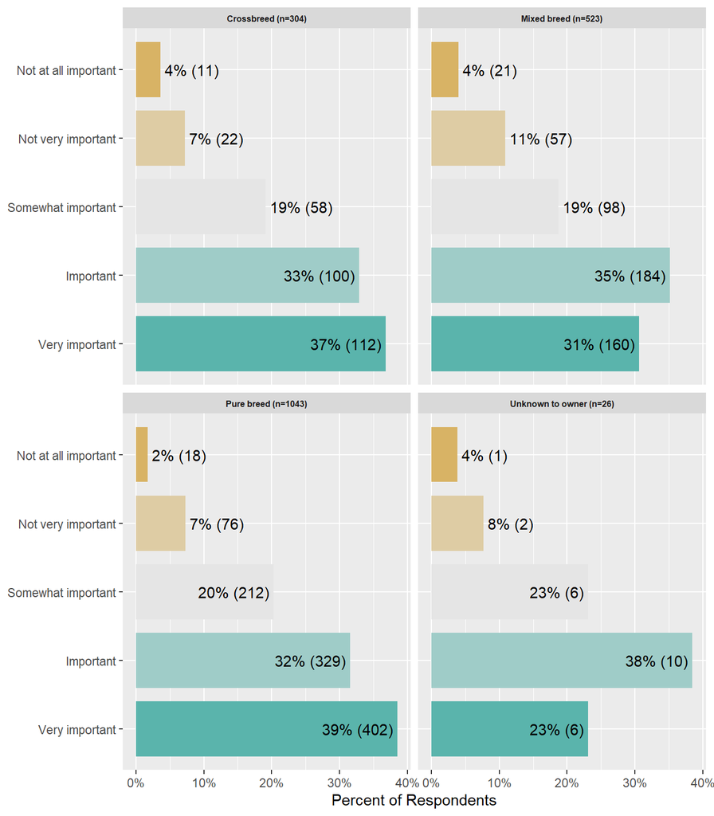

### > Q28r5

**Q28r5: Ability to meet the mother dog - How important were the following things in deciding where you got your puppy?**

1896 non-empty/NA responses out of 1896 possible responses ( 100 %)

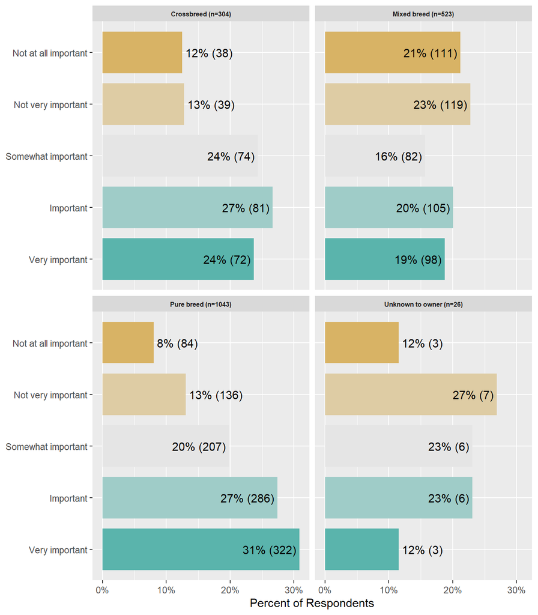

### > Q28r6

**Q28r6: Potential to breed the dog - How important were the following things in deciding where you got your puppy?**

1896 non-empty/NA responses out of 1896 possible responses ( 100 %)

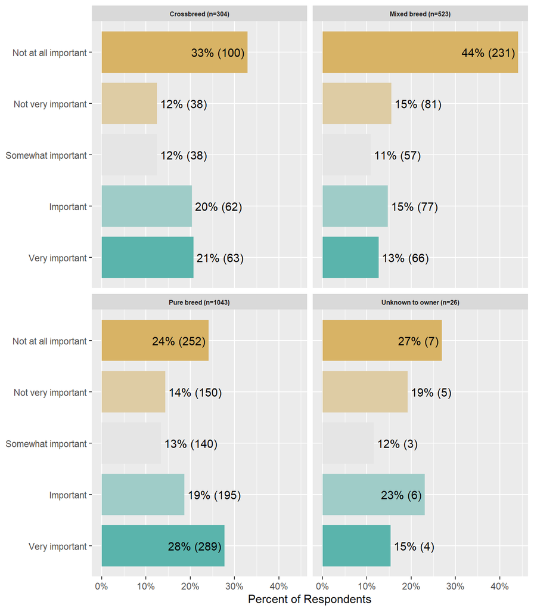

### > Q28r7

**Q28r7: Recommendation from trusted source - How important were the following things in deciding where you got your puppy?**

1896 non-empty/NA responses out of 1896 possible responses ( 100 %)

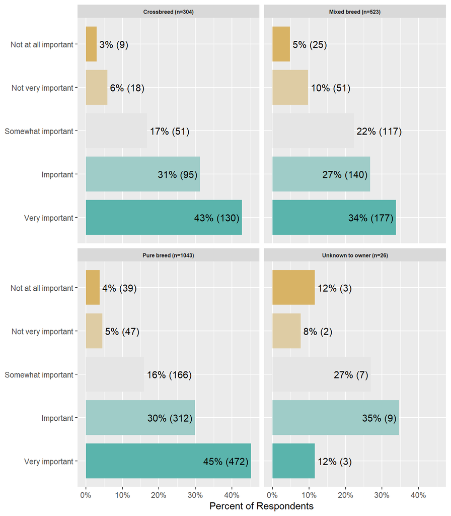

### > Q28r8

**Q28r8: Good communication and support - How important were the following things in deciding where you got your puppy?**

1896 non-empty/NA responses out of 1896 possible responses ( 100 %)

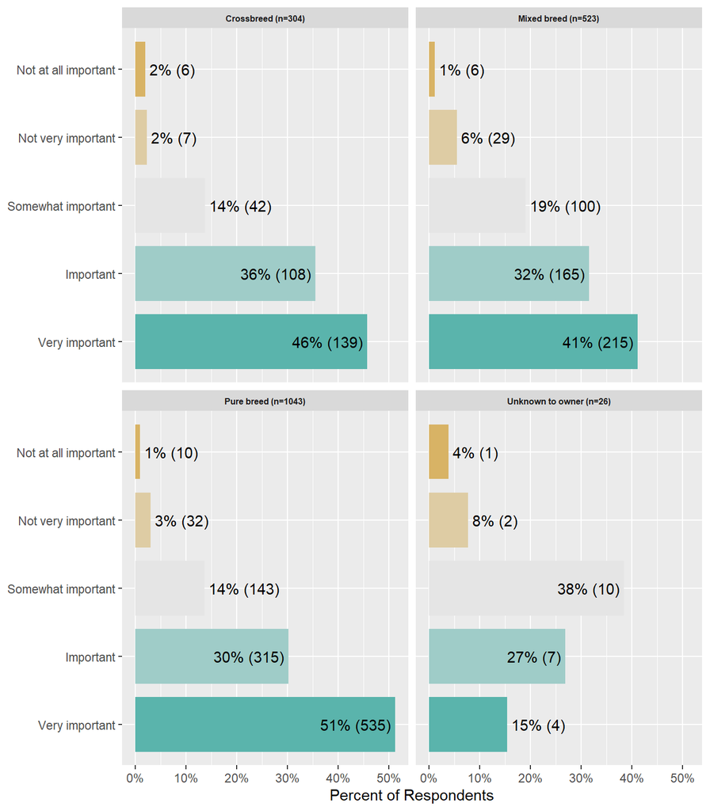

## Q29

**Q29: How much did you pay for your puppy?**

4002 non-empty/NA responses out of 4002 possible responses ( 100 %)

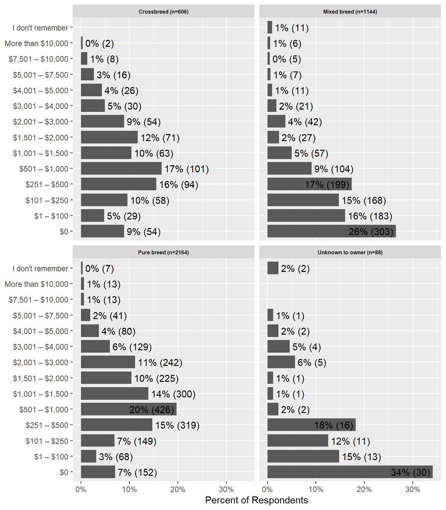

## Q34_new

**(NEW CLASSIFICATION) Q34: Where did your puppy come from? Please select the best match.**

4002 non-empty/NA responses out of 4002 possible responses ( 100 %)

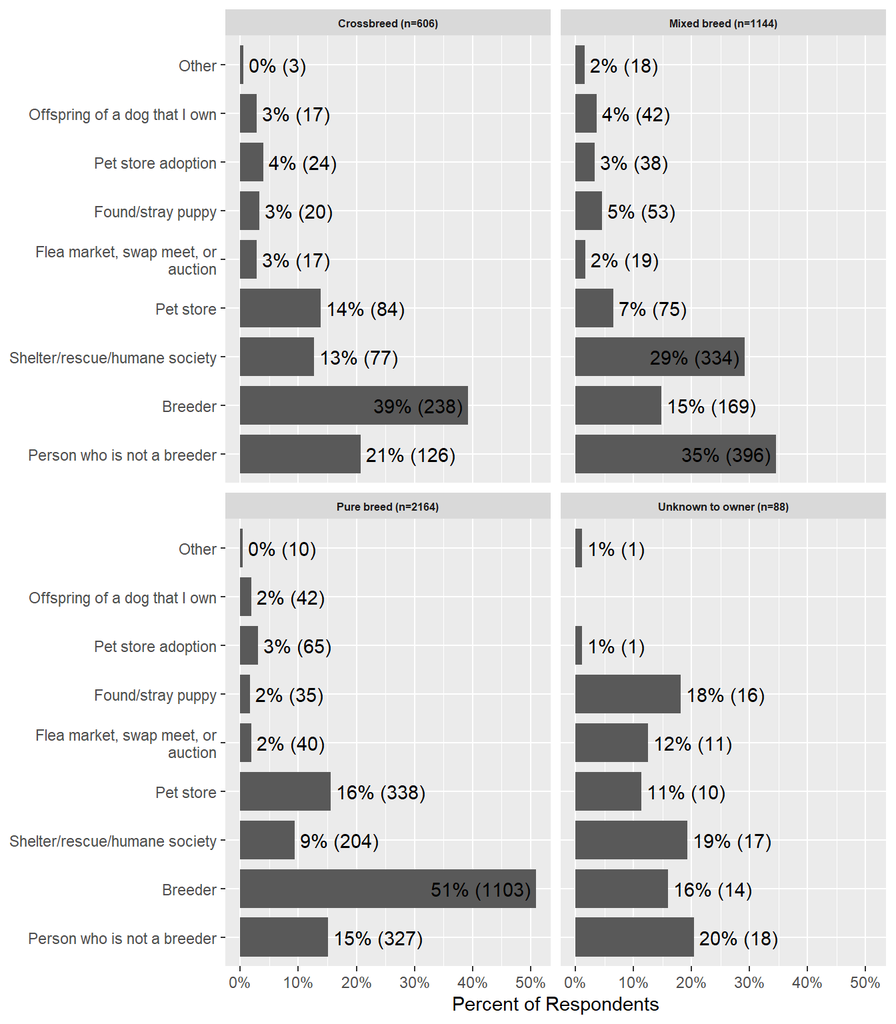

## Group B Only (…)

**Group B Only**

### > Q94

**Q94: Overall, how satisfied are you with your new puppy?**

2001 non-empty/NA responses out of 2001 possible responses ( 100 %)

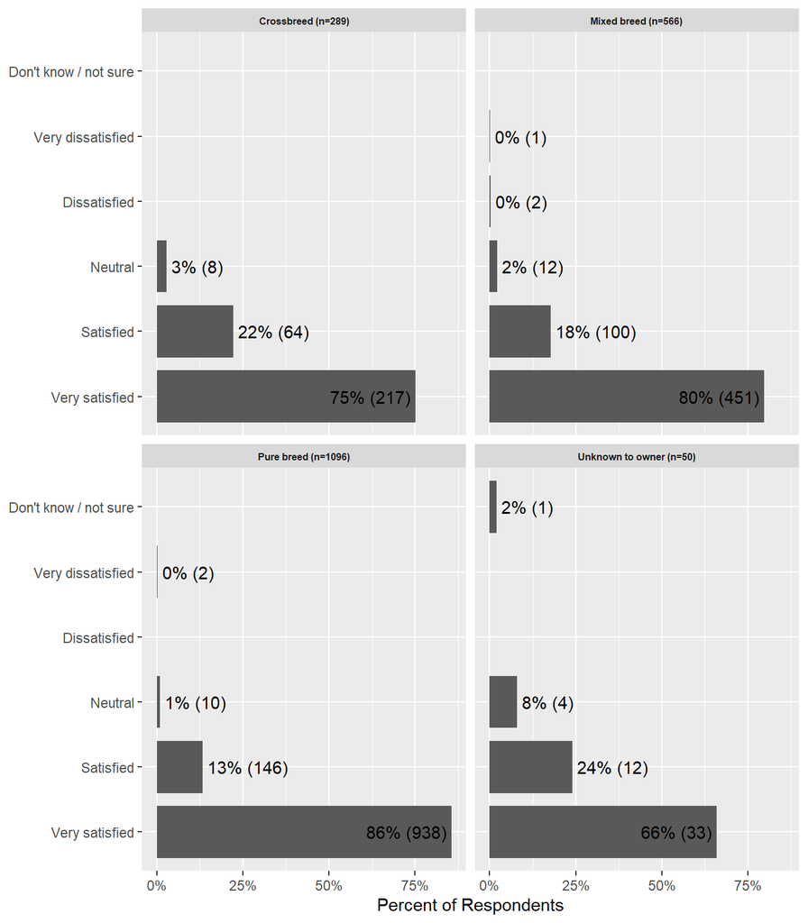

### > Q95

**Q95: How would you describe your puppy’s overall health?**

2001 non-empty/NA responses out of 2001 possible responses ( 100 %)

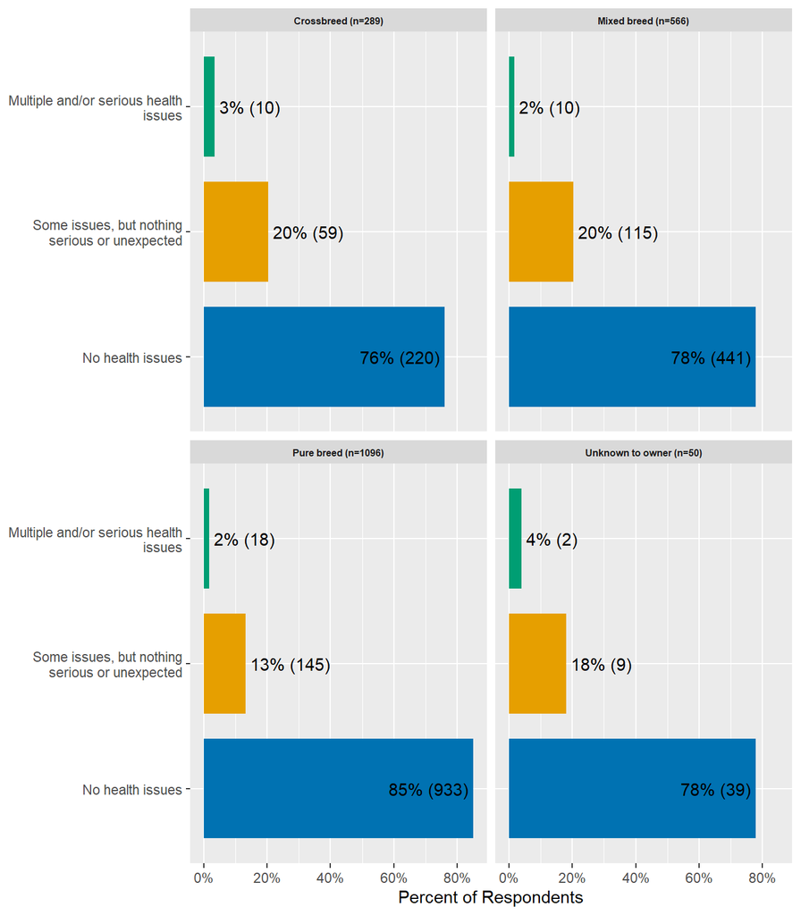

### > Q97

**Q97: How would you describe your puppy’s overall behavior?**

2001 non-empty/NA responses out of 2001 possible responses ( 100 %)

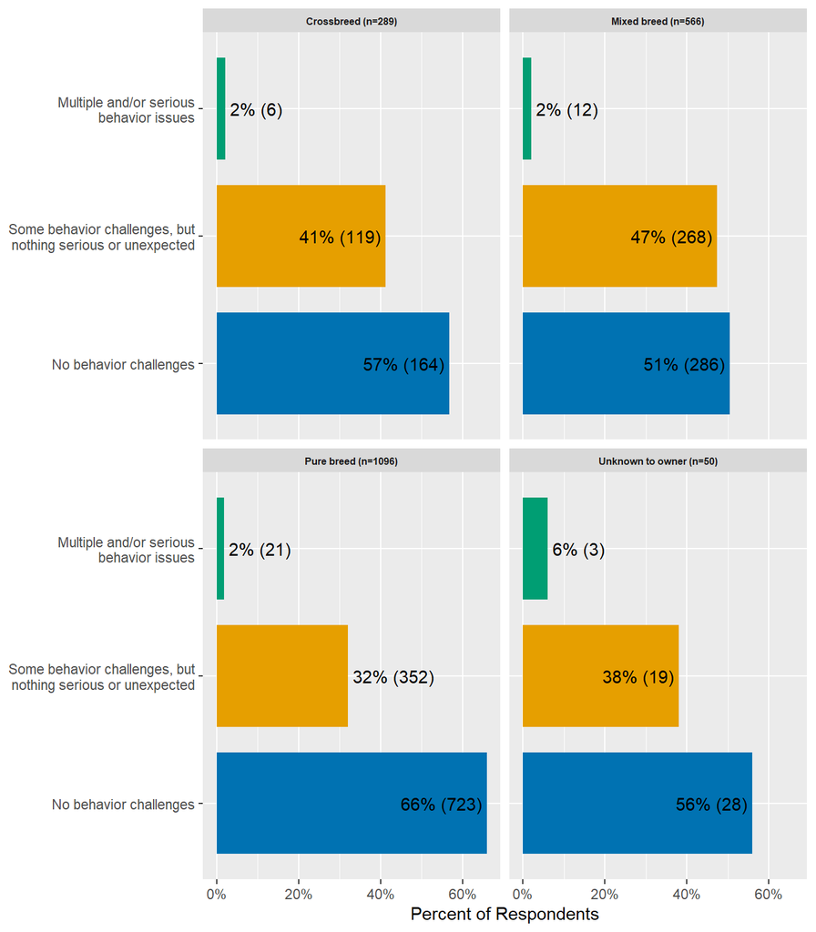

### > Q99

**Have you had challenges or concerns about any of the following?**

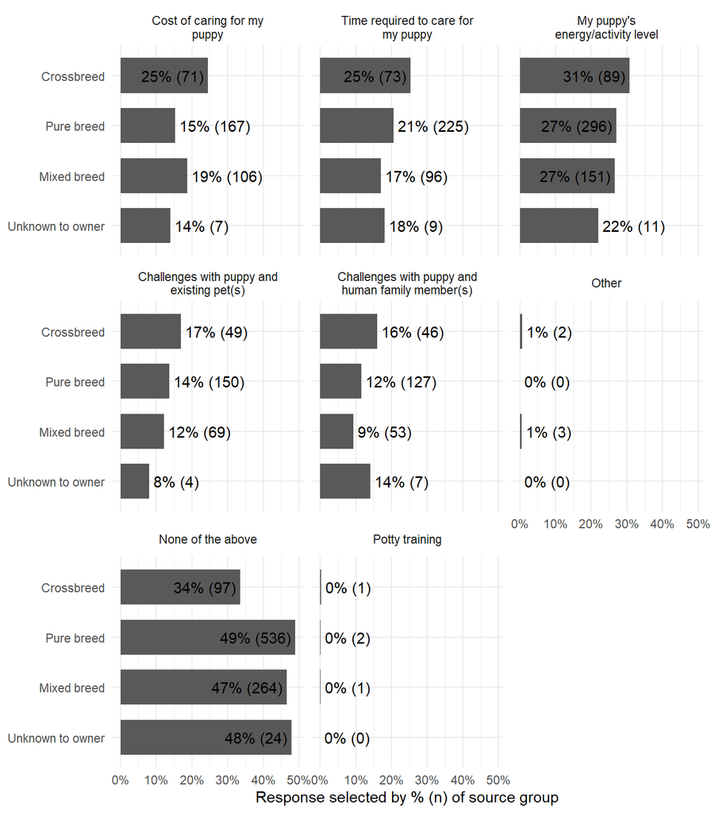